# HW2

b05702032

2017年10月5日

1. 年紀與花費習慣的關係

年輕人消費時較為衝動，可能造成鉅額卡債，透過不同年齡層的卡費比較，可以看出資料中年輕族群是否花費較高。

```r
library(dplyr)
data <- read.csv("customer.csv", header=T, sep=",")
mutate(data,cardspent+card2spent)
```

[output not shown]

[output cut: 288 more lines]

```r
data <-data%>%
  mutate(spendtotal = cardspent+card2spent)
```

以每400元做為花費的區間，每10歲一個區間

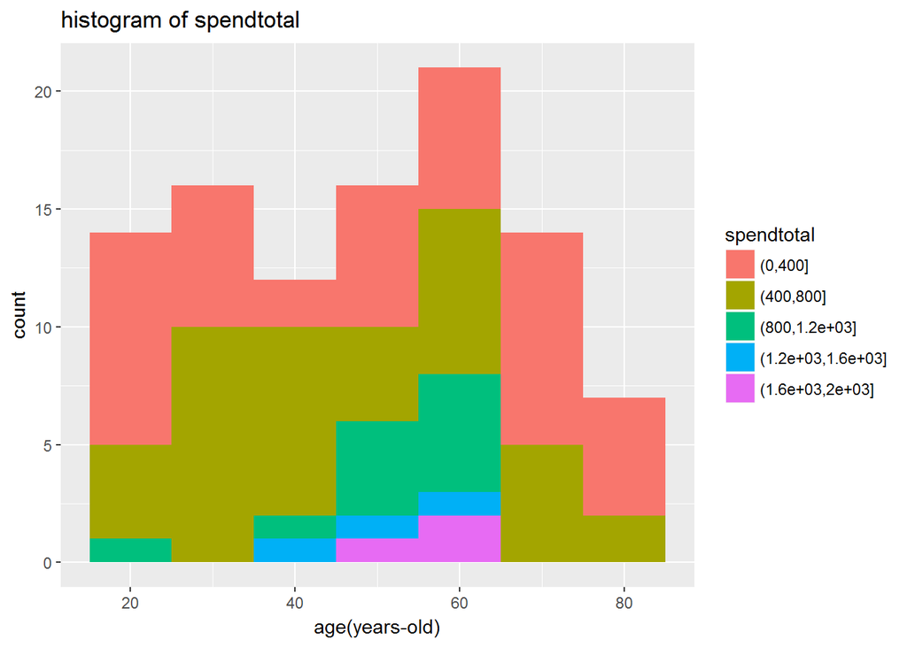

```r
data$spendtotal<- cut(data$spendtotal, seq(0,2000,400))
require(ggplot2)
qplot(x=age,data=data,geom = "histogram",main = "histogram of spendtotal",xlab="age(years-old)",binwidth=10,fill=spendtotal
)
```

2. 教育程度與收入是否成正比

通常教育程度高，薪資也相對較高，透過圖表，可以以看出是否資料與此情況相符。

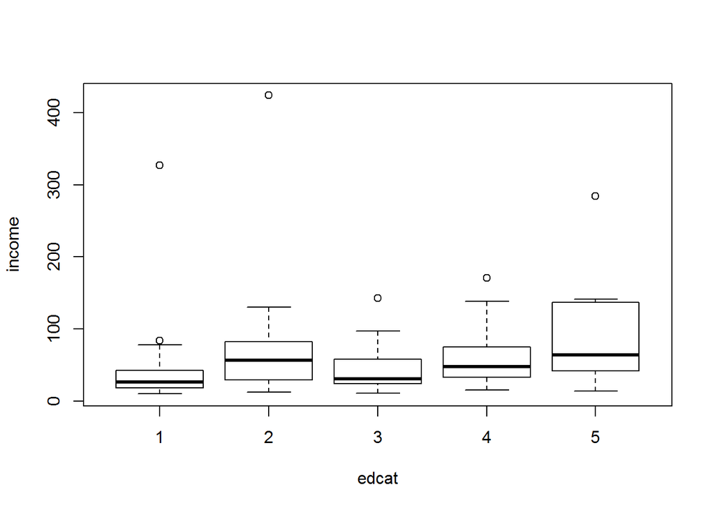

```r
  data3<-select(data,edcat,income)
boxplot(formula=income~edcat,data=data3,
        xlab="edcat",
        ylab="income",
        color="lightblue")
```

分析結果: 以盒狀圖來看，教育程度為5的整體收入分布較高，而教育程度為1的整體收入較低，除了教育程度為2的收入表現較突出，其餘的大致上隨著教育程度升高，有更高的收入。

3.年紀和地區的關係

每個地區年齡分布不同，想藉由圖表看出是否有高齡化問題及各地區年齡層分布。

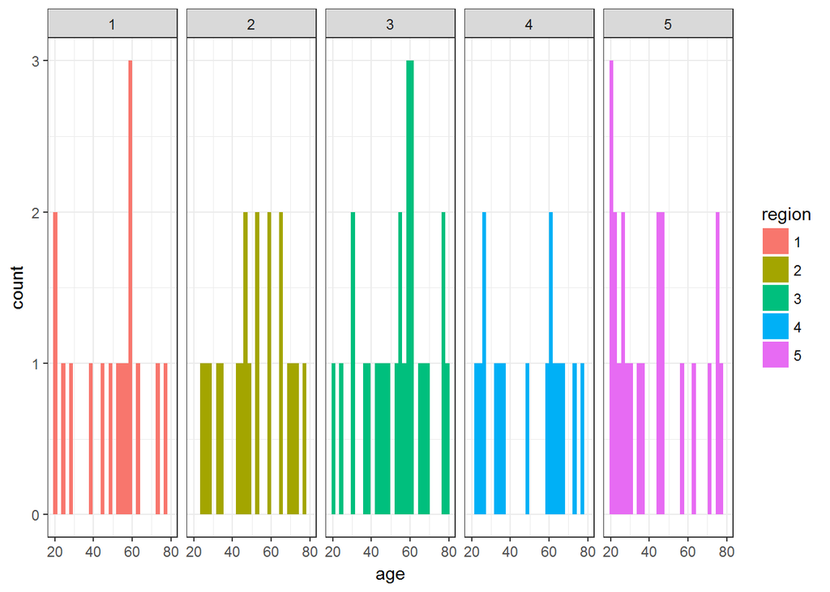

```r
data4<-data%>%select(region,age)
data4$region<-as.factor(data4$region)
require(ggplot2)


canvas<-ggplot(data=data4)
canvas+geom_histogram(aes(x=age,fill=region))+facet_grid(.~region)+theme_bw()
```